# Prediction

Theo Livingwell

October 10, 2017

Data was collected from 6 subjects wearing accelerometers on the belt, forearm, arm, and dumbell. # They performed barbell lifts correctly and incorrectly in 5 different ways.

Load required required packages

```r
library(caret)
library(randomForest)
```

load test and training data from local computer. Store them in train_data and test_data. Data came from http://web.archive.org/web/20161224072740/http:/groupware.les.inf.puc-rio.br/har

```r
train_data <- read.csv("D:/Document/Supplement/Data_Sci/PML/pml-training.csv", header = TRUE)

test_data <- read.csv("D:/Document/Supplement/Data_Sci/PML/pml-testing.csv", header=TRUE)

str(train_data)
```

```
## 'data.frame':    19622 obs. of  160 variables:
##  $ X                       : int  1 2 3 4 5 6 7 8 9 10 ...
##  $ user_name               : Factor w/ 6 levels "adelmo","carlitos",..: 2 2 2 2 2 2 2 2 2 2 ...
##  $ raw_timestamp_part_1    : int  1323084231 1323084231 1323084231 1323084232 1323084232 1323084232 1323084232 1323084232 1323084232 1323084232 ...
##  $ raw_timestamp_part_2    : int  788290 808298 820366 120339 196328 304277 368296 440390 484323 484434 ...
##  $ cvtd_timestamp          : Factor w/ 20 levels "02-12-11 13:32",..: 9 9 9 9 9 9 9 9 9 9 ...
##  $ new_window              : Factor w/ 2 levels "no","yes": 1 1 1 1 1 1 1 1 1 1 ...
##  $ num_window              : int  11 11 11 12 12 12 12 12 12 12 ...
##  $ roll_belt               : num  1.41 1.41 1.42 1.48 1.48 1.45 1.42 1.42 1.43 1.45 ...
##  $ pitch_belt              : num  8.07 8.07 8.07 8.05 8.07 8.06 8.09 8.13 8.16 8.17 ...
##  $ yaw_belt                : num  -94.4 -94.4 -94.4 -94.4 -94.4 -94.4 -94.4 -94.4 -94.4 -94.4 ...
##  $ total_accel_belt        : int  3 3 3 3 3 3 3 3 3 3 ...
##  $ kurtosis_roll_belt      : Factor w/ 397 levels "","-0.01685",..: 1 1 1 1 1 1 1 1 1 1 ...
##  $ kurtosis_picth_belt     : Factor w/ 317 levels "","-0.021887",..: 1 1 1 1 1 1 1 1 1 1 ...
##  $ kurtosis_yaw_belt       : Factor w/ 2 levels "","#DIV/0!": 1 1 1 1 1 1 1 1 1 1 ...
```

[output cut: 86 more lines]

```r
str(test_data)
```

```
## 'data.frame':    20 obs. of  160 variables:
##  $ X                       : int  1 2 3 4 5 6 7 8 9 10 ...
##  $ user_name               : Factor w/ 6 levels "adelmo","carlitos",..: 6 5 5 1 4 5 5 5 2 3 ...
##  $ raw_timestamp_part_1    : int  1323095002 1322673067 1322673075 1322832789 1322489635 1322673149 1322673128 1322673076 1323084240 1322837822 ...
##  $ raw_timestamp_part_2    : int  868349 778725 342967 560311 814776 510661 766645 54671 916313 384285 ...
##  $ cvtd_timestamp          : Factor w/ 11 levels "02-12-11 13:33",..: 5 10 10 1 6 11 11 10 3 2 ...
##  $ new_window              : Factor w/ 1 level "no": 1 1 1 1 1 1 1 1 1 1 ...
##  $ num_window              : int  74 431 439 194 235 504 485 440 323 664 ...
##  $ roll_belt               : num  123 1.02 0.87 125 1.35 -5.92 1.2 0.43 0.93 114 ...
##  $ pitch_belt              : num  27 4.87 1.82 -41.6 3.33 1.59 4.44 4.15 6.72 22.4 ...
##  $ yaw_belt                : num  -4.75 -88.9 -88.5 162 -88.6 -87.7 -87.3 -88.5 -93.7 -13.1 ...
##  $ total_accel_belt        : int  20 4 5 17 3 4 4 4 4 18 ...
##  $ kurtosis_roll_belt      : logi  NA NA NA NA NA NA ...
##  $ kurtosis_picth_belt     : logi  NA NA NA NA NA NA ...
##  $ kurtosis_yaw_belt       : logi  NA NA NA NA NA NA ...
```

[output cut: 86 more lines]

Lets remove covariates that are close to zero and store in ctzc variable

```r
ctzc <- nearZeroVar(train_data,saveMetrics=TRUE)
train_data <- train_data[,!ctzc$nzv]
test_data <- test_data[,!ctzc$nzv]
```

Filter missing values from train_data and test_data, then reassign to train_data2 and test_data2 respectively

```r
train_data2 <- train_data[,(colSums(is.na(train_data)) == 0)]
test_data2 <- test_data[,(colSums(is.na(test_data)) == 0)]
```

Now delete unwanted columns

```r
colDel_train_data<- c("user_name","raw_timestamp_part_1","raw_timestamp_part_2","cvtd_timestamp","num_window")
colDel_test_data <- c("user_name","raw_timestamp_part_1","raw_timestamp_part_2","cvtd_timestamp","num_window","problem_id")

train_colDel <- train_data2[,!(names(train_data2) %in% colDel_train_data)]
test_colDel <- test_data2[,!(names(test_data2) %in% colDel_test_data)]

dim(test_colDel)
```

```
## [1] 20 53
```

```r
dim(train_colDel)
```

```
## [1] 19622    54
```

split training data into 2 sets: validation set and training set. The new varable are split_train and split_validate

```r
newTrain_data <- createDataPartition(y=train_data$classe, p=0.7, list=FALSE)
split_train <- train_colDel[newTrain_data,]
split_validate <- train_colDel[-newTrain_data,]
```

```r
data_correlation <- abs(sapply(colnames(split_train[, -ncol(train_data)]), function(x) cor(as.numeric(split_train[, x]), as.numeric(split_train$classe), method = "spearman")))
```

# I shal try to fit a random forest model and check how it performance on the validation set

```r
set.seed(1000)

regressor_line <- train(classe ~ ., method = "rf", data=split_train, importance = T, trControl = trainControl(method = "cv", number = 3))
spec_validation <- predict(regressor_line, newdata=split_validate)
```

check model’s output

```r
confusionMatrix(spec_validation,split_validate$classe)
```

```
## Confusion Matrix and Statistics
##
##           Reference
## Prediction    A    B    C    D    E
##          A 1674    0    0    0    0
##          B    0 1139    0    0    0
##          C    0    0 1026    0    0
##          D    0    0    0  964    0
##          E    0    0    0    0 1082
##
## Overall Statistics
##
##                Accuracy : 1
##                  95% CI : (0.9994, 1)
##     No Information Rate : 0.2845
##     P-Value [Acc > NIR] : < 2.2e-16
##
##                   Kappa : 1
##  Mcnemar's Test P-Value : NA
##
## Statistics by Class:
##
##                      Class: A Class: B Class: C Class: D Class: E
## Sensitivity            1.0000   1.0000   1.0000   1.0000   1.0000
## Specificity            1.0000   1.0000   1.0000   1.0000   1.0000
## Pos Pred Value         1.0000   1.0000   1.0000   1.0000   1.0000
## Neg Pred Value         1.0000   1.0000   1.0000   1.0000   1.0000
## Prevalence             0.2845   0.1935   0.1743   0.1638   0.1839
## Detection Rate         0.2845   0.1935   0.1743   0.1638   0.1839
## Detection Prevalence   0.2845   0.1935   0.1743   0.1638   0.1839
## Balanced Accuracy      1.0000   1.0000   1.0000   1.0000   1.0000
```

check relevant variables

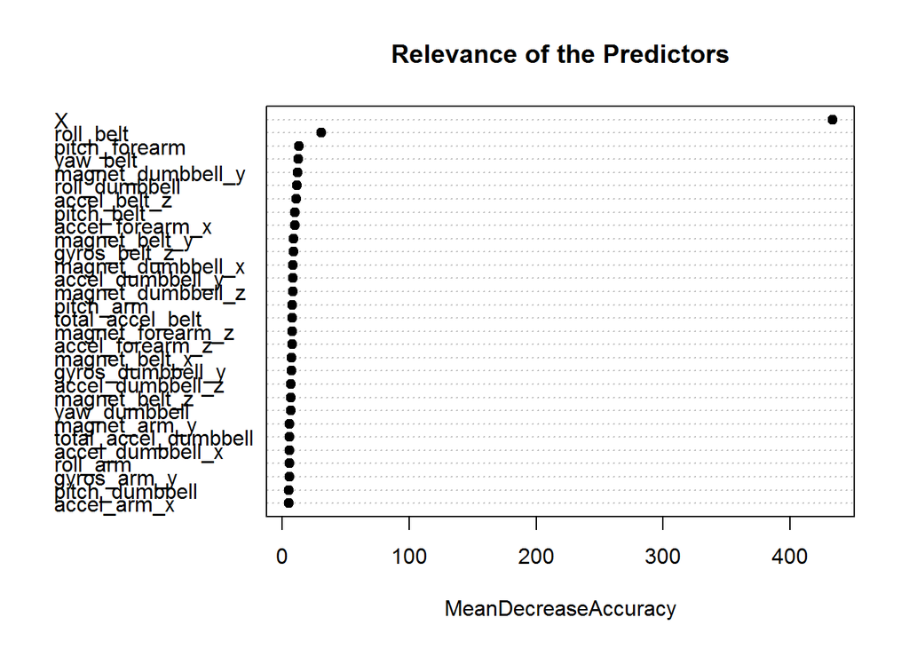

```r
relevant_var <- varImp(regressor_line)$importance
varImpPlot(regressor_line$finalModel, sort = TRUE, type = 1, pch = 19, col = 1, cex = 1, main = "Relevance of the Predictors")
```

Prediction

Now lets use randomForest model to predict on the testing dataset without the outcome variable and save the prediction output.

```
testing_prediction <- predict(regressor_line, newdata=test_colDel)
writeFiles <- function(x) {
        p <- length(x)
        for (i in 1:p) {
                file_name <- paste0("problem_id", i, ".txt")
                write.table(x[i], file=file_name, quote=FALSE, row.names=FALSE,col.names=FALSE)
        }
}
writeFiles(testing_prediction)
```